# Data Manipulation with R: Soil pore data

Edward Wallace, ewjwallace@gmail.com

1/24/2018

# Why use R for data science?

We need to interpret and understand our data. To do this, we need to import, tidy, transform, visualize, and model data.

R makes this all *efficient*, *flexible*, and *reproducible*. With practice, you can not only make common things happen fast and knowing exactly what has happened, but you can access a wide variety of powerful tools to visualize and model your data. For free.

## Great resources on web and print

Data Carpentry: http://www.datacarpentry.org/R-ecology-lesson/

R for Data Science, Garrett Grolemund and Hadley Wickham: http://r4ds.had.co.nz/

Fundamentals of Data Visualization, Claus Wilke: http://serialmentor.com/dataviz/

Stack Overflow: https://stackoverflow.com/questions/tagged/r

Look for your local R meetup: https://www.meetup.com/LondonR/

# Description of Soil Pore dataset

We (Amin Garbout) have CT-scanned the same soil, before rain (br), after rain (ar) and after a drying phase (ad).

We separated pores into 2 main categories:

_cross : are pores that permit the drainages as they connect the soil surface to the below ground of the soil _unc : are pores not connected to surface, they do not play a major role in water transport but have importance for soil structure

We measured key parameters from CT images:

ID : pore id Vol : Volume (mm$^3$) of the pore x.Cent, y.Cent, z. Cent : centre of the pore in x, y, z co-ordinates (mm) Thickness, SD.Thickness, Max.Thickness : Mean, SD, Max thickness/ diameter of the pore (mm) SA : Surface area of the pore (mm)

# Start: examples of base R functions

R can do arithmetic, and store many kinds of data: numbers, strings, and more.

```r
1+1
```

```
## [1] 2
```

```r
my_number = 1000
my_subject = "stomata"

my_number
```

```
## [1] 1000
```

```r
str(my_number)
```

```
##  num 1000
```

```r
str(my_subject)
```

```
##  chr "stomata"
```

## How to ask for Help

Importantly, you can ask for help using a question mark

```r
?str

?base
```

Starting to type a command and pressing the tab key for suggestions is also a good idea.

# Many helpful collections of R functions are in packages

We’re going to use the package “tidyverse”

```r
# install.packages("tidyverse")
library(tidyverse)
```

This loads sub-packages for importing (readr), tidying (tibble), transforming (tidyr), and visualizing (ggplot2) data.

# Load data for before-rain cross.

We load the data with read_csv, which makes a “tibble”. A tibble is a nicer version of the base-R “data frame” that holds many kinds of data in columns, where each row is one observation. This is like a more structured version of an excel table

```r
br_122_cross = read_csv("data/br_122_cross.csv")
?read_csv
br_122_cross
```

```
## # A tibble: 73 x 12
##       X1   X.x          Label.x  ID.x Vol...mm..x x.Cent..mm..x
##    <int> <int>            <chr> <int>       <dbl>         <dbl>
##  1     1     1 br_122_Cross.tif     1   673.91000         13.41
##  2    10    10 br_122_Cross.tif    10     0.00000         27.54
##  3    11    11 br_122_Cross.tif    11     0.00091         28.39
##  4    12    12 br_122_Cross.tif    12     0.00001         31.00
##  5    13    13 br_122_Cross.tif    13     0.01000         25.21
##  6    14    14 br_122_Cross.tif    14     0.01000         13.74
##  7    15    15 br_122_Cross.tif    15     0.00004         27.61
##  8    16    16 br_122_Cross.tif    16     0.00065         19.31
##  9    17    17 br_122_Cross.tif    17     0.00007         26.90
## 10    18    18 br_122_Cross.tif    18     0.00003         19.43
## # ... with 63 more rows, and 6 more variables: y.Cent..mm..x <dbl>,
## #   z.Cent..mm..x <dbl>, Thickness..mm. <dbl>, SD.Thickness..mm. <dbl>,
## #   Max.Thickness..mm. <dbl>, SA..mm. <dbl>
```

## Examine it

Number of rows, structure, names, extract a single column.

```r
nrow(br_122_cross)
```

```
## [1] 73
```

```r
str(br_122_cross)
```

```
## Classes 'tbl_df', 'tbl' and 'data.frame':    73 obs. of  12 variables:
##  $ X1                : int  1 10 11 12 13 14 15 16 17 18 ...
##  $ X.x               : int  1 10 11 12 13 14 15 16 17 18 ...
##  $ Label.x           : chr  "br_122_Cross.tif" "br_122_Cross.tif" "br_122_Cross.tif" "br_122_Cross.tif" ...
##  $ ID.x              : int  1 10 11 12 13 14 15 16 17 18 ...
##  $ Vol...mm..x       : num  6.74e+02 0.00 9.10e-04 1.00e-05 1.00e-02 ...
##  $ x.Cent..mm..x     : num  13.4 27.5 28.4 31 25.2 ...
##  $ y.Cent..mm..x     : num  7.77 11.61 11.6 11.62 11.68 ...
##  $ z.Cent..mm..x     : num  16.31 0.08 0.03 0 0.21 ...
##  $ Thickness..mm.    : num  0.13 0.09 0.08 0.05 0.09 0.1 0.05 0.06 0.05 0.05 ...
##  $ SD.Thickness..mm. : num  0.05 0.02 0.02 0 0.02 0.03 0 0.01 0 0 ...
##  $ Max.Thickness..mm.: num  0.45 0.12 0.1 0.05 0.11 0.14 0.05 0.07 0.05 0.05 ...
##  $ SA..mm.           : num  1.83e+04 1.70e-01 3.32e-02 0.00 2.26e-01 ...
##  - attr(*, "spec")=List of 2
##   ..$ cols   :List of 12
##   .. ..$ X1                : list()
##   .. .. ..- attr(*, "class")= chr  "collector_integer" "collector"
##   .. ..$ X.x               : list()
##   .. .. ..- attr(*, "class")= chr  "collector_integer" "collector"
##   .. ..$ Label.x           : list()
##   .. .. ..- attr(*, "class")= chr  "collector_character" "collector"
##   .. ..$ ID.x              : list()
##   .. .. ..- attr(*, "class")= chr  "collector_integer" "collector"
##   .. ..$ Vol...mm..x       : list()
##   .. .. ..- attr(*, "class")= chr  "collector_double" "collector"
##   .. ..$ x.Cent..mm..x     : list()
##   .. .. ..- attr(*, "class")= chr  "collector_double" "collector"
##   .. ..$ y.Cent..mm..x     : list()
##   .. .. ..- attr(*, "class")= chr  "collector_double" "collector"
##   .. ..$ z.Cent..mm..x     : list()
##   .. .. ..- attr(*, "class")= chr  "collector_double" "collector"
##   .. ..$ Thickness..mm.    : list()
##   .. .. ..- attr(*, "class")= chr  "collector_double" "collector"
##   .. ..$ SD.Thickness..mm. : list()
##   .. .. ..- attr(*, "class")= chr  "collector_double" "collector"
##   .. ..$ Max.Thickness..mm.: list()
##   .. .. ..- attr(*, "class")= chr  "collector_double" "collector"
##   .. ..$ SA..mm.           : list()
##   .. .. ..- attr(*, "class")= chr  "collector_double" "collector"
##   ..$ default: list()
##   .. ..- attr(*, "class")= chr  "collector_guess" "collector"
##   ..- attr(*, "class")= chr "col_spec"
```

```r
names(br_122_cross)
```

```
##  [1] "X1"                 "X.x"                "Label.x"
##  [4] "ID.x"               "Vol...mm..x"        "x.Cent..mm..x"
##  [7] "y.Cent..mm..x"      "z.Cent..mm..x"      "Thickness..mm."
## [10] "SD.Thickness..mm."  "Max.Thickness..mm." "SA..mm."
```

```r
br_122_cross$X1
```

```
##  [1]  1 10 11 12 13 14 15 16 17 18 19  2 20 21 22 23 24 25 26 27 28 29  3
## [24] 30 31 32 33 34 35 36 37 38 39  4 40 41 42 43 44 45 46 47 48 49  5 50
## [47] 51 52 53 54 55 56 57 58 59  6 60 61 62 63 64 65 66 67 68 69  7 70 71
## [70] 72 73  8  9
```

Note that str gives too much information.

## Some of these columns look redundant, are they exactly the same?

```r
all.equal(br_122_cross$X1,br_122_cross$X.x)
```

```
## [1] TRUE
```

```r
all.equal(br_122_cross$X1,br_122_cross$X.x)
```

```
## [1] TRUE
```

## Choose nicer column names and reload

We pick names. Then use set_names to set those.

```r
pore_col_names = c("ID","ID1","Source","ID2","Vol",
           "x.Cent","y.Cent","z.Cent",
           "Thickness","SD.Thickness","Max.Thickness","SA")
br_122_cross_renamed <-
    set_names(br_122_cross,pore_col_names)

br_122_cross_renamed
```

```
## # A tibble: 73 x 12
##       ID   ID1           Source   ID2       Vol x.Cent y.Cent z.Cent
##    <int> <int>            <chr> <int>     <dbl>  <dbl>  <dbl>  <dbl>
##  1     1     1 br_122_Cross.tif     1 673.91000  13.41   7.77  16.31
##  2    10    10 br_122_Cross.tif    10   0.00000  27.54  11.61   0.08
##  3    11    11 br_122_Cross.tif    11   0.00091  28.39  11.60   0.03
##  4    12    12 br_122_Cross.tif    12   0.00001  31.00  11.62   0.00
##  5    13    13 br_122_Cross.tif    13   0.01000  25.21  11.68   0.21
##  6    14    14 br_122_Cross.tif    14   0.01000  13.74  11.92   0.25
##  7    15    15 br_122_Cross.tif    15   0.00004  27.61  11.78   0.02
##  8    16    16 br_122_Cross.tif    16   0.00065  19.31  11.87   0.06
##  9    17    17 br_122_Cross.tif    17   0.00007  26.90  11.87   0.01
## 10    18    18 br_122_Cross.tif    18   0.00003  19.43  11.91   0.01
## # ... with 63 more rows, and 4 more variables: Thickness <dbl>,
## #   SD.Thickness <dbl>, Max.Thickness <dbl>, SA <dbl>
```

### Select only some (non-redundant) columns

We select some columns we want. Or select to remove some columns.

```r
select(br_122_cross_renamed,ID,Source,Vol,Thickness)
```

```
## # A tibble: 73 x 4
##       ID           Source       Vol Thickness
##    <int>            <chr>     <dbl>     <dbl>
##  1     1 br_122_Cross.tif 673.91000      0.13
##  2    10 br_122_Cross.tif   0.00000      0.09
##  3    11 br_122_Cross.tif   0.00091      0.08
##  4    12 br_122_Cross.tif   0.00001      0.05
##  5    13 br_122_Cross.tif   0.01000      0.09
##  6    14 br_122_Cross.tif   0.01000      0.10
##  7    15 br_122_Cross.tif   0.00004      0.05
##  8    16 br_122_Cross.tif   0.00065      0.06
##  9    17 br_122_Cross.tif   0.00007      0.05
## 10    18 br_122_Cross.tif   0.00003      0.05
## # ... with 63 more rows
```

```r
select(br_122_cross_renamed,-ID1,-ID2)
```

```
## # A tibble: 73 x 10
##       ID           Source       Vol x.Cent y.Cent z.Cent Thickness
##    <int>            <chr>     <dbl>  <dbl>  <dbl>  <dbl>     <dbl>
##  1     1 br_122_Cross.tif 673.91000  13.41   7.77  16.31      0.13
##  2    10 br_122_Cross.tif   0.00000  27.54  11.61   0.08      0.09
##  3    11 br_122_Cross.tif   0.00091  28.39  11.60   0.03      0.08
##  4    12 br_122_Cross.tif   0.00001  31.00  11.62   0.00      0.05
##  5    13 br_122_Cross.tif   0.01000  25.21  11.68   0.21      0.09
##  6    14 br_122_Cross.tif   0.01000  13.74  11.92   0.25      0.10
##  7    15 br_122_Cross.tif   0.00004  27.61  11.78   0.02      0.05
##  8    16 br_122_Cross.tif   0.00065  19.31  11.87   0.06      0.06
##  9    17 br_122_Cross.tif   0.00007  26.90  11.87   0.01      0.05
## 10    18 br_122_Cross.tif   0.00003  19.43  11.91   0.01      0.05
## # ... with 63 more rows, and 3 more variables: SD.Thickness <dbl>,
## #   Max.Thickness <dbl>, SA <dbl>
```

### Pipe to remove redundant columns.

So far we’ve applied one function at a time and created a new tibble every time. This results in many objects that it’s hard to keep track of, and code that is hard to follow and maintain.

The pipe operator %>% takes the output of the function before, and supplies it in place of the first argument to the next function. This makes it easier to chain many functions together and read your code.

```r
pore_col_names = c("ID","ID1","Source","ID2","Vol",
           "x.Cent","y.Cent","z.Cent",
           "Thickness","SD.Thickness","Max.Thickness","SA")

read_csv("data/br_122_cross.csv") %>%
    set_names(pore_col_names)
```

```
## # A tibble: 73 x 12
##       ID   ID1           Source   ID2       Vol x.Cent y.Cent z.Cent
##    <int> <int>            <chr> <int>     <dbl>  <dbl>  <dbl>  <dbl>
##  1     1     1 br_122_Cross.tif     1 673.91000  13.41   7.77  16.31
##  2    10    10 br_122_Cross.tif    10   0.00000  27.54  11.61   0.08
##  3    11    11 br_122_Cross.tif    11   0.00091  28.39  11.60   0.03
##  4    12    12 br_122_Cross.tif    12   0.00001  31.00  11.62   0.00
##  5    13    13 br_122_Cross.tif    13   0.01000  25.21  11.68   0.21
##  6    14    14 br_122_Cross.tif    14   0.01000  13.74  11.92   0.25
##  7    15    15 br_122_Cross.tif    15   0.00004  27.61  11.78   0.02
##  8    16    16 br_122_Cross.tif    16   0.00065  19.31  11.87   0.06
##  9    17    17 br_122_Cross.tif    17   0.00007  26.90  11.87   0.01
## 10    18    18 br_122_Cross.tif    18   0.00003  19.43  11.91   0.01
## # ... with 63 more rows, and 4 more variables: Thickness <dbl>,
## #   SD.Thickness <dbl>, Max.Thickness <dbl>, SA <dbl>
```

```r
br_122_cross = read_csv("data/br_122_cross.csv") %>%
    set_names(pore_col_names) %>%
    select(-ID1,-ID2)
br_122_cross
```

```
## # A tibble: 73 x 10
##       ID           Source       Vol x.Cent y.Cent z.Cent Thickness
##    <int>            <chr>     <dbl>  <dbl>  <dbl>  <dbl>     <dbl>
##  1     1 br_122_Cross.tif 673.91000  13.41   7.77  16.31      0.13
##  2    10 br_122_Cross.tif   0.00000  27.54  11.61   0.08      0.09
##  3    11 br_122_Cross.tif   0.00091  28.39  11.60   0.03      0.08
##  4    12 br_122_Cross.tif   0.00001  31.00  11.62   0.00      0.05
##  5    13 br_122_Cross.tif   0.01000  25.21  11.68   0.21      0.09
##  6    14 br_122_Cross.tif   0.01000  13.74  11.92   0.25      0.10
##  7    15 br_122_Cross.tif   0.00004  27.61  11.78   0.02      0.05
##  8    16 br_122_Cross.tif   0.00065  19.31  11.87   0.06      0.06
##  9    17 br_122_Cross.tif   0.00007  26.90  11.87   0.01      0.05
## 10    18 br_122_Cross.tif   0.00003  19.43  11.91   0.01      0.05
## # ... with 63 more rows, and 3 more variables: SD.Thickness <dbl>,
## #   Max.Thickness <dbl>, SA <dbl>
```

### Filter observations

Filter lets us to choose rows with some feature that we want: for example, pores with non-zero thickness.

```r
br_122_cross_renamed %>%
    select(ID,Vol,Thickness) %>%
    filter(Thickness > 0)
```

```
## # A tibble: 73 x 3
##       ID       Vol Thickness
##    <int>     <dbl>     <dbl>
##  1     1 673.91000      0.13
##  2    10   0.00000      0.09
##  3    11   0.00091      0.08
##  4    12   0.00001      0.05
##  5    13   0.01000      0.09
##  6    14   0.01000      0.10
##  7    15   0.00004      0.05
##  8    16   0.00065      0.06
##  9    17   0.00007      0.05
## 10    18   0.00003      0.05
## # ... with 63 more rows
```

## Summary of every column of the data

```r
summary(br_122_cross)
```

```
##        ID        Source               Vol               x.Cent
##  Min.   : 1   Length:73          Min.   :  0.0000   Min.   : 0.19
##  1st Qu.:19   Class :character   1st Qu.:  0.0000   1st Qu.: 8.16
##  Median :37   Mode  :character   Median :  0.0002   Median :16.28
##  Mean   :37                      Mean   :  9.3170   Mean   :16.00
##  3rd Qu.:55                      3rd Qu.:  0.0100   3rd Qu.:22.28
##  Max.   :73                      Max.   :673.9100   Max.   :31.00
##      y.Cent          z.Cent        Thickness        SD.Thickness
##  Min.   : 7.77   Min.   : 0.00   Min.   :0.05000   Min.   :0.00000
##  1st Qu.:11.73   1st Qu.: 0.05   1st Qu.:0.05000   1st Qu.:0.00000
##  Median :11.91   Median :30.79   Median :0.08000   Median :0.01000
##  Mean   :11.83   Mean   :17.01   Mean   :0.07753   Mean   :0.01342
##  3rd Qu.:12.11   3rd Qu.:31.33   3rd Qu.:0.09000   3rd Qu.:0.02000
##  Max.   :12.61   Max.   :31.36   Max.   :0.16000   Max.   :0.08000
##  Max.Thickness          SA
##  Min.   :0.0500   Min.   :    0.000
##  1st Qu.:0.0500   1st Qu.:    0.000
##  Median :0.0800   Median :    0.031
##  Mean   :0.1037   Mean   :  253.545
##  3rd Qu.:0.1400   3rd Qu.:    0.282
##  Max.   :0.4500   Max.   :18336.147
```

# Tables are hard to understand: start visualizing

## Visualize x-and y-positions of pores

ggplot (for grammar of graphics plot) is a powerful structured way of plotting data. You need data in a tibble or data frame. Then you choose aesthetics, which are a way of mapping columns to plot features (position, size, colour, …), and a geom which specifies how to do the mapping.

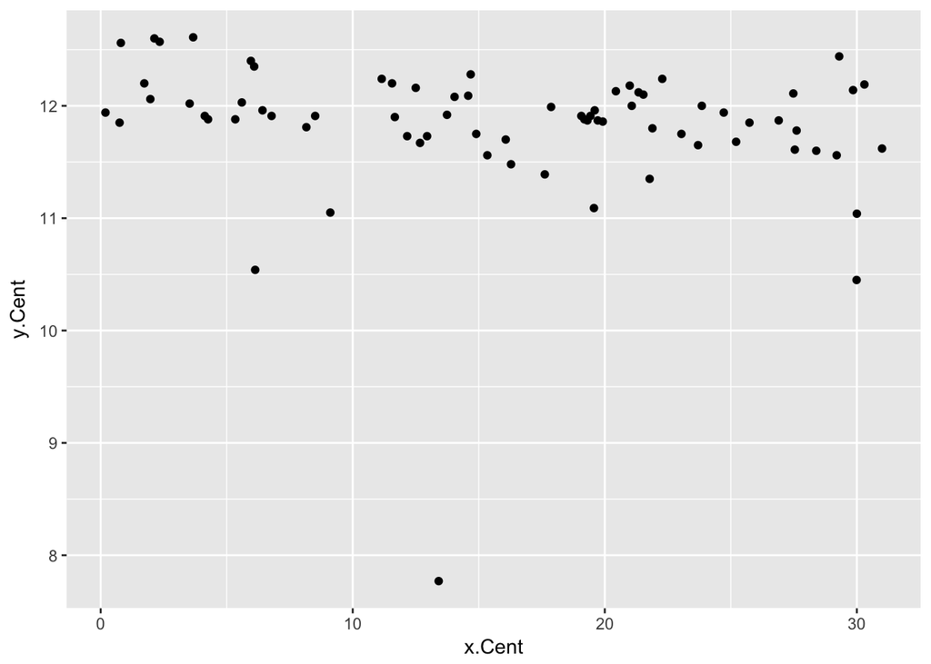

```r
ggplot(data=br_122_cross,aes(x=x.Cent,y=y.Cent)) +
    geom_point()
```

## Exercise: Visualize x- and z-positions

## Visualize Volume as size and and x- and y-position

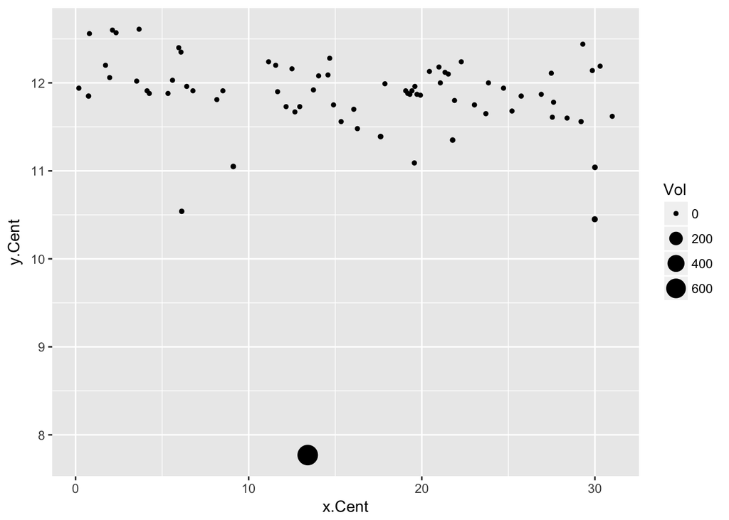

```r
ggplot(data=br_122_cross,aes(x=x.Cent,y=y.Cent,size=Vol)) +
    geom_point()
```

## Consider outlying point separately

Reminder, filter accesses defined rows of the data.

```r
br_122_cross %>%
    filter(y.Cent < 9)
```

```
## # A tibble: 1 x 10
##      ID           Source    Vol x.Cent y.Cent z.Cent Thickness
##   <int>            <chr>  <dbl>  <dbl>  <dbl>  <dbl>     <dbl>
## 1     1 br_122_Cross.tif 673.91  13.41   7.77  16.31      0.13
## # ... with 3 more variables: SD.Thickness <dbl>, Max.Thickness <dbl>,
## #   SA <dbl>
```

```r
br_122_cross %>%
    filter(y.Cent > 9)
```

```
## # A tibble: 72 x 10
##       ID           Source     Vol x.Cent y.Cent z.Cent Thickness
##    <int>            <chr>   <dbl>  <dbl>  <dbl>  <dbl>     <dbl>
##  1    10 br_122_Cross.tif 0.00000  27.54  11.61   0.08      0.09
##  2    11 br_122_Cross.tif 0.00091  28.39  11.60   0.03      0.08
##  3    12 br_122_Cross.tif 0.00001  31.00  11.62   0.00      0.05
##  4    13 br_122_Cross.tif 0.01000  25.21  11.68   0.21      0.09
##  5    14 br_122_Cross.tif 0.01000  13.74  11.92   0.25      0.10
##  6    15 br_122_Cross.tif 0.00004  27.61  11.78   0.02      0.05
##  7    16 br_122_Cross.tif 0.00065  19.31  11.87   0.06      0.06
##  8    17 br_122_Cross.tif 0.00007  26.90  11.87   0.01      0.05
##  9    18 br_122_Cross.tif 0.00003  19.43  11.91   0.01      0.05
## 10    19 br_122_Cross.tif 0.00007  19.60  11.96   0.01      0.05
## # ... with 62 more rows, and 3 more variables: SD.Thickness <dbl>,
## #   Max.Thickness <dbl>, SA <dbl>
```

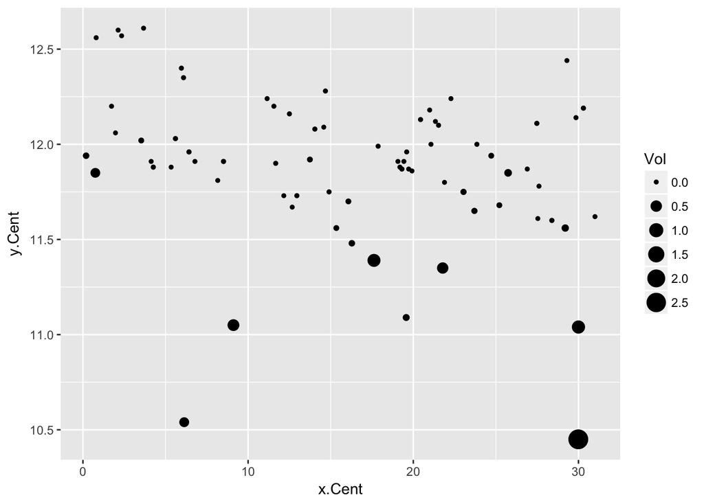

```r
ggplot(data=br_122_cross %>%
    filter(y.Cent > 9),
    aes(x=x.Cent,y=y.Cent,size=Vol)) +
    geom_point()
```

## Exercise: Load After Rain, cross, and visualize position-volume relation

From file “ar_122_cross.csv”

# Put things you do again and again into functions

If we want to load multiple datasets in a very similar way, we can:

- Copy and paste the same code with minor adjustments
- Write a function

Writing functions is less error-prone and takes up less space. We’ve “chunked” - made a complicated task into a simple sub-task.

## Load pore data function

Mutate creates new or changed columns in a tibble. Here we use it to include the Soil and Pore category

```r
load_pore_data = function(File,Soil,Cat) {
    read_csv(File) %>%
        set_names(pore_col_names) %>%
        mutate(Soil=Soil,Cat=Cat)
}

br_122_unc = load_pore_data("data/br_122_unc.csv","br","unc")
```

## Now can we load all the soil conditions and pore categories?

Yes. With three pore types, and two pore categories, we can make a small tibble keeping track of all of those and the filenames (wiht mutate).

```r
soil_types = c("br","ar","ad")
pore_cats = c("cross","unc")

crossing(Soil=soil_types,Cat=pore_cats)
```

```
## # A tibble: 6 x 2
##    Soil   Cat
##   <chr> <chr>
## 1    ad cross
## 2    ad   unc
## 3    ar cross
## 4    ar   unc
## 5    br cross
## 6    br   unc
```

```r
combinations = crossing(Soil=soil_types,Cat=pore_cats) %>%
    mutate(File=paste0("data/",Soil,"_122_",Cat,".csv"))

combinations
```

```
## # A tibble: 6 x 3
##    Soil   Cat                  File
##   <chr> <chr>                 <chr>
## 1    ad cross data/ad_122_cross.csv
## 2    ad   unc   data/ad_122_unc.csv
## 3    ar cross data/ar_122_cross.csv
## 4    ar   unc   data/ar_122_unc.csv
## 5    br cross data/br_122_cross.csv
## 6    br   unc   data/br_122_unc.csv
```

# Use group_by and do to load all data

“group_by” tells our tibble we’d like it broken up a certain way.

“do” applies an arbitrary function to the output

Note: The syntax is a challenge. After a “pipe” (%>%) then the dot “.” is used to refer to the thing, or grouped thing, that is fed in to the function.

```r
combinations %>%
    group_by(Cat,Soil)
```

```
## # A tibble: 6 x 3
## # Groups:   Cat, Soil [6]
##    Soil   Cat                  File
##   <chr> <chr>                 <chr>
## 1    ad cross data/ad_122_cross.csv
## 2    ad   unc   data/ad_122_unc.csv
## 3    ar cross data/ar_122_cross.csv
## 4    ar   unc   data/ar_122_unc.csv
## 5    br cross data/br_122_cross.csv
## 6    br   unc   data/br_122_unc.csv
```

```r
pores_data =
    combinations %>%
    group_by(Cat,Soil) %>%
    do(load_pore_data(File=.$File,Cat=.$Cat,Soil=.$Soil))
```

## Summarize the data by group

Summarize is a simpler version of do for functions that return single values, not tibbles.

```r
groups(pores_data)
```

```
## [[1]]
## Cat
##
## [[2]]
## Soil
```

```r
pores_data %>%
    group_by(Cat,Soil) %>%
    summarize(Vol.mean=mean(Vol),SA.mean=mean(SA),
              Thickness.mean=mean(Thickness))
```

```
## # A tibble: 6 x 5
## # Groups:   Cat [?]
##     Cat  Soil     Vol.mean      SA.mean Thickness.mean
##   <chr> <chr>        <dbl>        <dbl>          <dbl>
## 1 cross    ad 0.1566671053   2.85584658     0.14657895
## 2 cross    ar 0.0500850000   1.00810955     0.12090909
## 3 cross    br 9.3169910959 253.54493301     0.07753425
## 4   unc    ad 0.0017877213   0.05034831     0.06501838
## 5   unc    ar 0.0023386071   0.06413157     0.07022103
## 6   unc    br 0.0005131432   0.01924358     0.05646332
```

Here we see that there are differences in thickness between soils. We will shortly return to visualize that.

## Write the cleaned, assembled data

Yes, there are functions for writing data, too, making it easier to return to.

```r
write_csv(pores_data,"data/pores_data_122.csv")
```

### Load data afresh from here if needed

```r
pores_data = read_csv("data/pores_data_122.csv")
```

# Visualize differences between soil conditions

## Histogram of Thickness for all cross pores

Here we filter by equality. Double equals “==” tests for equality, different from single equals.

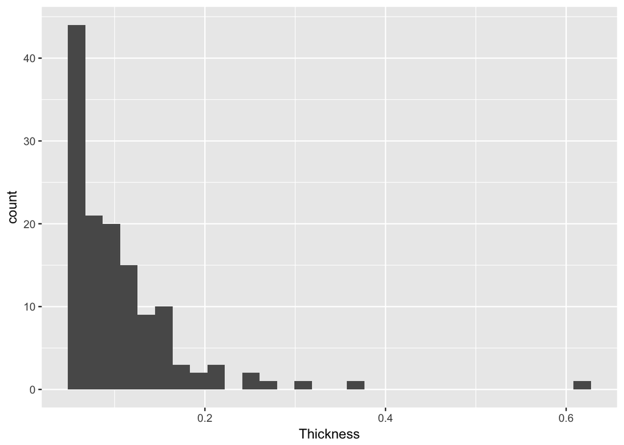

```r
ggplot(data=pores_data %>%
           filter(Cat=="cross"),
       aes(x=Thickness)) +
      geom_histogram()
```

## Plot same data as a density curve

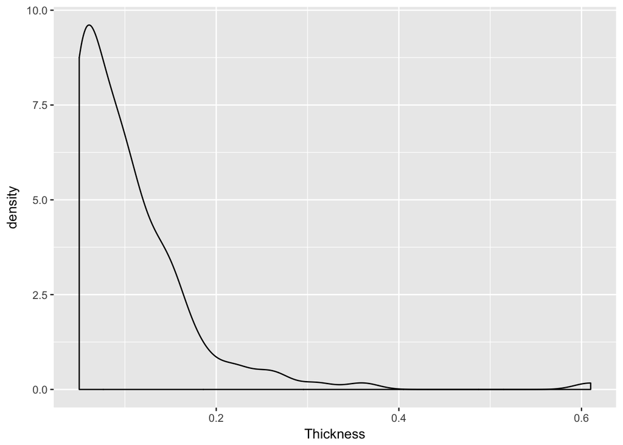

```r
ggplot(data=pores_data %>%
           filter(Cat=="cross"),
       aes(x=Thickness)) +
      geom_density()
```

## Difference in pore thickness distribution by Soil

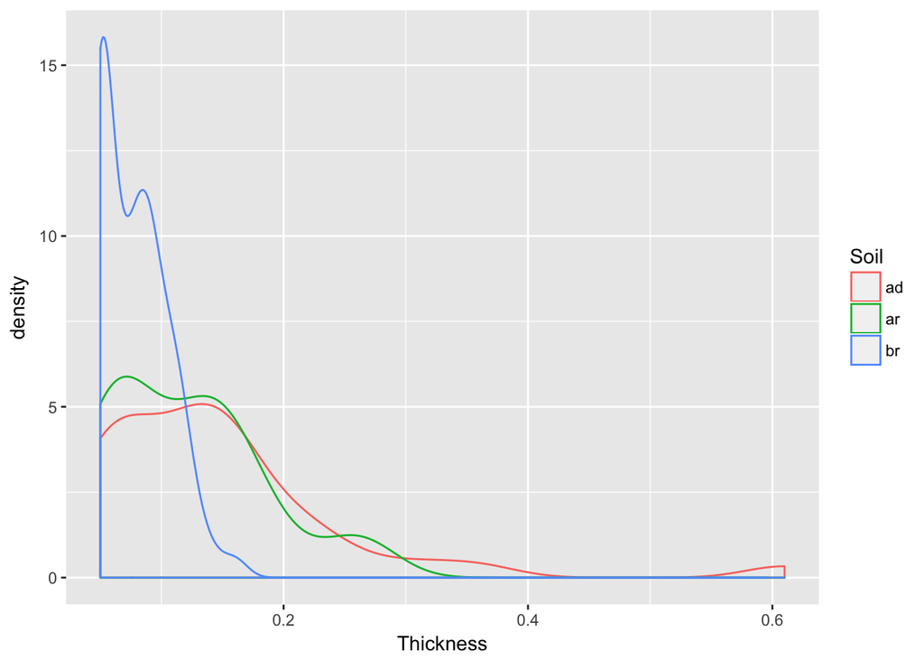

```r
ggplot(data=pores_data %>%
           filter(Cat=="cross"),
       aes(x=Thickness,colour=Soil)) +
      geom_density()
```

## Exercise: does Thickness vary with soil type for uncrossed pores?

## Exercise: does that look better as a histogram?

## Example: other features that let us produce high-quality plots

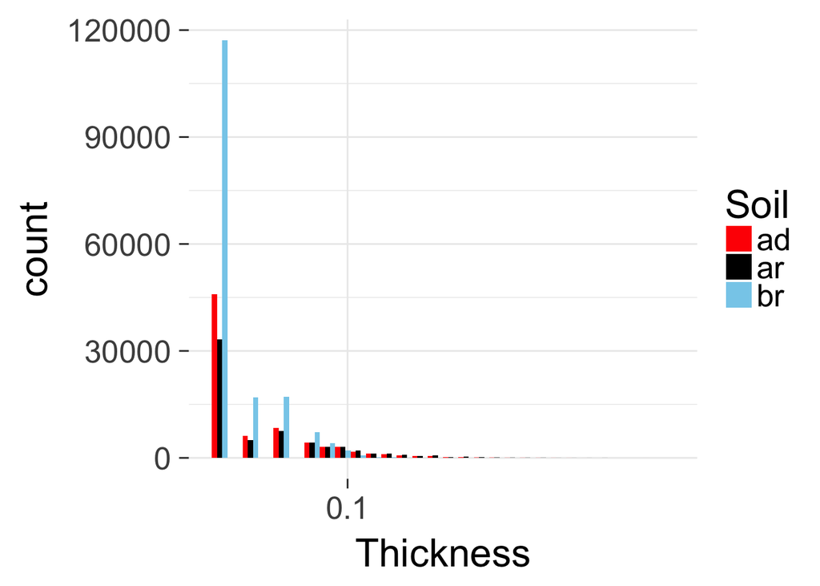

```r
ggplot(data=pores_data %>% filter(Cat=="unc"),
       aes(x=Thickness,fill=Soil)) +
    geom_histogram(position="dodge") +
    theme_bw(base_size = 24) +
    theme(panel.border=element_blank()) +
    scale_x_log10() +
    scale_fill_manual(values=c(br="skyblue",ar="black",ad="red"))
```

# More on relationships between pairs of variables

## How are Volume and Surface Area related?

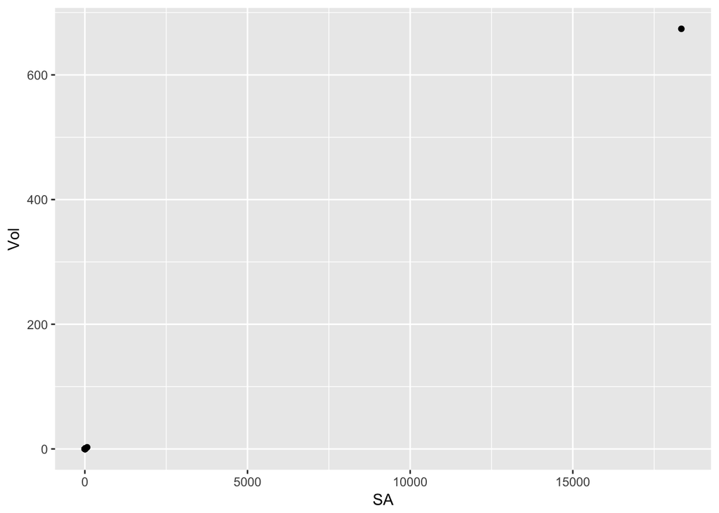

```r
ggplot(data=pores_data %>%
           filter(Cat=="cross"),
       aes(x=SA,y=Vol)) +
    geom_point()
```

### Change to log-scales

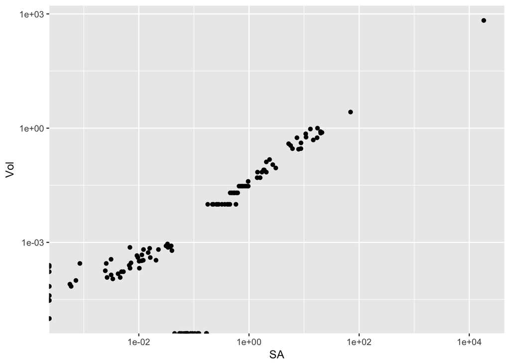

```r
ggplot(data=pores_data %>%
           filter(Cat=="cross"),
       aes(x=SA,y=Vol)) +
    geom_point() +
    scale_x_log10() +
    scale_y_log10()
```

## Exercise: are Thickness and SA related by soil type?

## How could we summarize this relation?

introducing stat_smooth, a statistical summary of the data

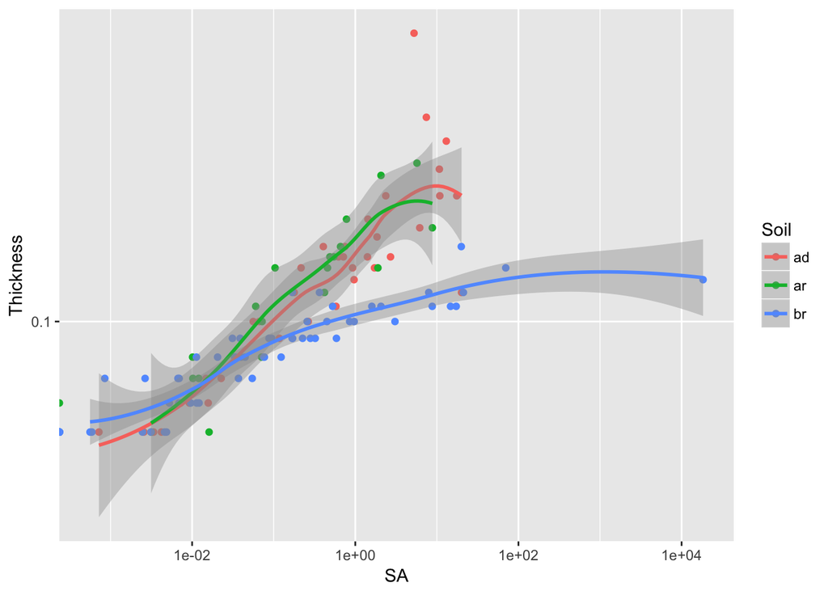

```r
ggplot(data=pores_data %>%
           filter(Cat=="cross"),
       aes(x=SA,y=Thickness,colour=Soil)) +
       geom_point() +
    stat_smooth() +
    scale_x_log10() +
    scale_y_log10()
```

stat_smooth automatically uses a local smoothing method called loess.

## Summarize dependencies visually with a linear model

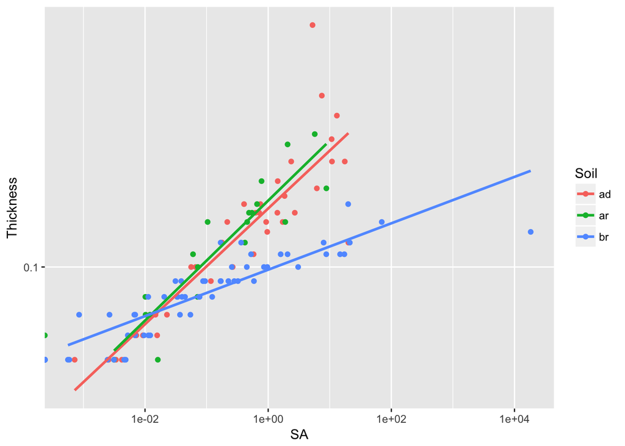

```r
ggplot(data=pores_data %>%
           filter(Cat=="cross"),
       aes(x=SA,y=Thickness,colour=Soil)) +
    geom_point() +
    stat_smooth(method="lm",se=FALSE) +
    scale_x_log10() +
    scale_y_log10()
```

## Exercise: What about in uncrossed pores?

## Use facet_wrap to plot unc separately from crossed

facet_wrap allows breaking the data into separate panels

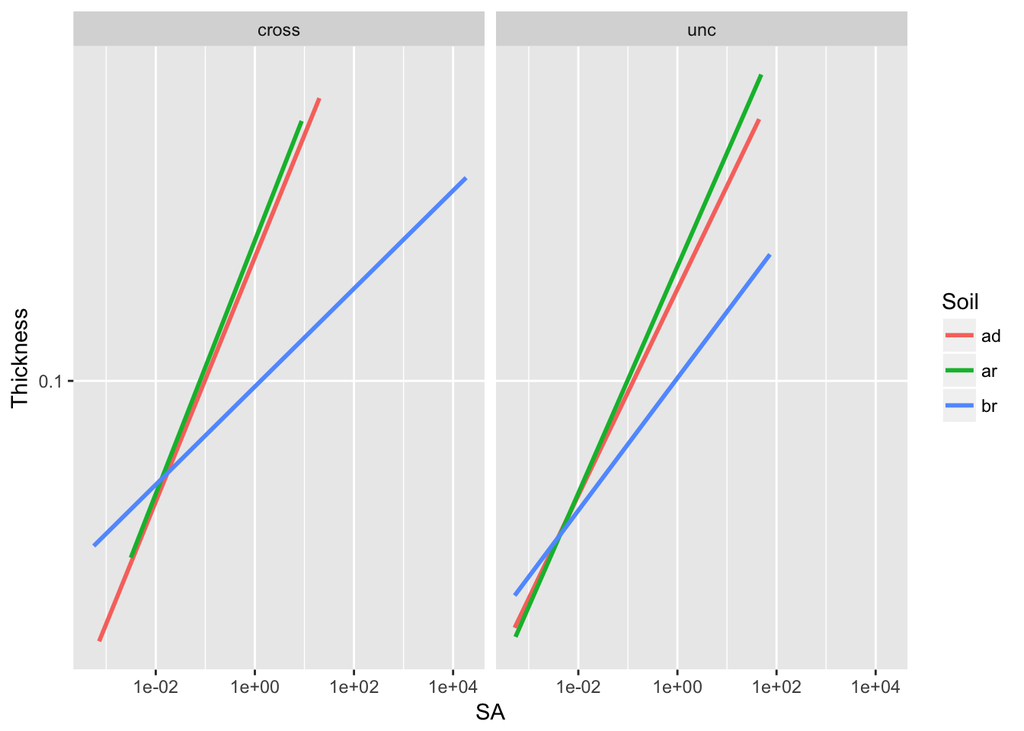

```r
ggplot(data=pores_data,
       aes(x=SA,y=Thickness,colour=Soil)) +
    # geom_point() +
    stat_smooth(method="lm",se=FALSE) +
    scale_x_log10() +
    scale_y_log10() +
    facet_wrap(~Cat)
```

## Use linetype aesthetic to see lines on same axes

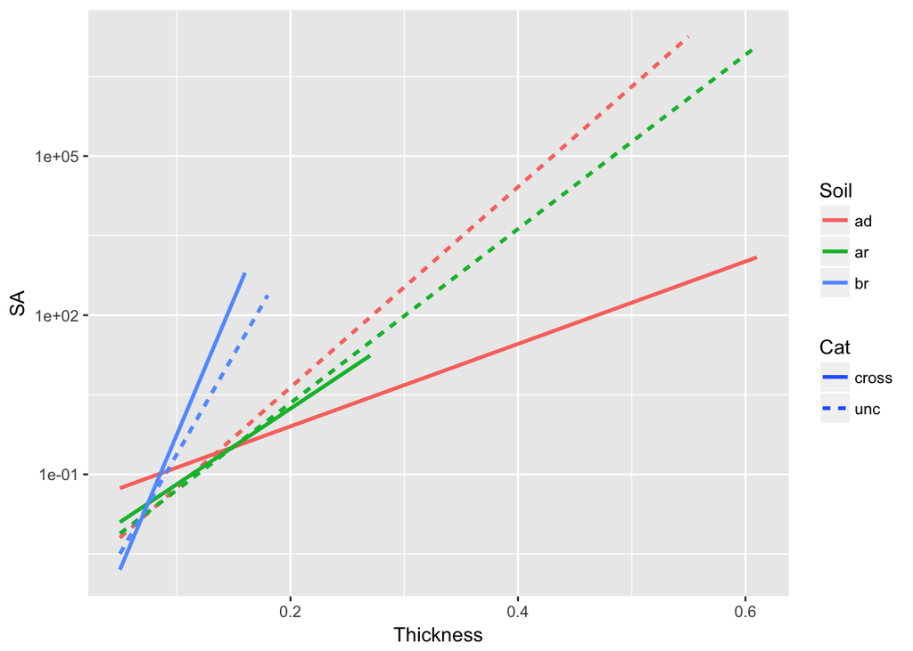

```r
ggplot(data=pores_data,
       aes(x=Thickness,y=SA,colour=Soil,linetype=Cat)) +
    stat_smooth(method="lm",se=FALSE) +
    scale_y_log10()
```

# What are the slopes of these lines? Use linear model(lm)

This is made hard by many steps involved.

## Sub-exercise: use a linear model to estimate relationship in one dataset

Note that the interesting correlation is with log10(SA); but in that case you have to remove the invalid values (log(0) = -Inf) to get the lm function to work.

## Use the broom package to tidy this output and wrap in a function

The broom package makes the outputs of linear models and so on into tidy tibbles.

```r
library(broom)

lm( data =  pores_data %>%
        filter(Thickness > 0, SA > 0 ),
    formula = log10(Thickness) ~ log10(SA)) %>%
    tidy()
```

```
##          term   estimate    std.error  statistic p.value
## 1 (Intercept) -0.8954407 0.0005159816 -1735.4120       0
## 2   log10(SA)  0.1435344 0.0002781583   516.0169       0
```

```r
lm_ThicknessSA = function(sub_data) {
    lm( data =  sub_data %>%
            filter(Thickness > 0, SA > 0 ),
        formula = log10(Thickness) ~ log10(SA)) %>%
    tidy()
}

lm_ThicknessSA(pores_data)
```

```
##          term   estimate    std.error  statistic p.value
## 1 (Intercept) -0.8954407 0.0005159816 -1735.4120       0
## 2   log10(SA)  0.1435344 0.0002781583   516.0169       0
```

### Sub-Exercise: use group_by and summarize to get the slopes of these lines.

### Exercise: use “breaks” so that the scale labels are informative, and “theme_bw” to change the appearance of the plot

## Some important topics we didn’t cover

Readxl: R can directly read excel spreadsheets and some other kinds of data.

Other plots: lines (geom_line), boxplots (geom_boxplot), heatmaps (geom_tile), 2-d density plots (geom_hex), …

Missing data: NA, na.omit, and so on.

Modeling: linear regression, clustering, etc.

All this and more can be done in R!